# Longitudinal G-Formula

2025-02-19

## The (longitudinal) g-formula

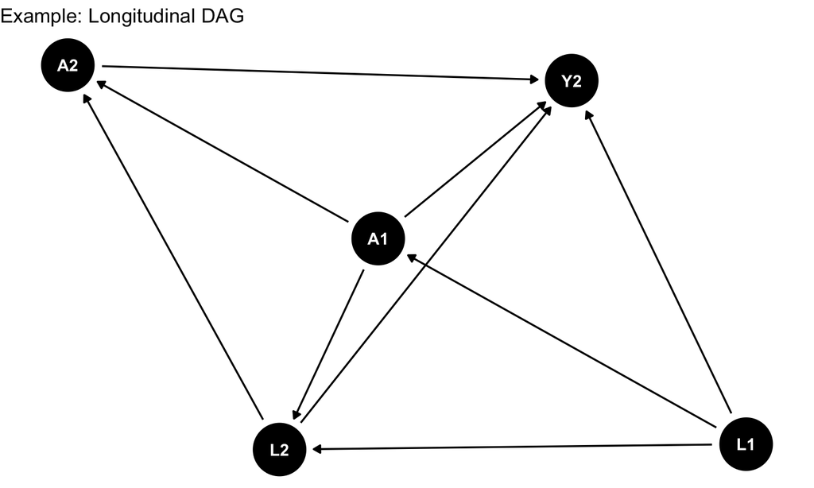

## The Monte Carlo Algorithm

The Monte Carlo algorithm can be used to estimate \(E(Y^g_2)\) or \(p(y_2^g)\):

1. Sample with replacement from the target population at time \(k=0\), \(\hat{p}(l_1) = \hat{p}_n(l_1)\) (**pseudo-population**, \(N^g\))
2. Set \(A_1\) equal to \(g\) for everyone in the pseudo-population
3. Simulate values from \(L_2\) from \(p(l_2|g, l_1)\)
- For example, a Bernoulli distribution with \(\mu = p(l_2|g,l_1)\)
1. Simulate values of \(Y_2\) from \(p(Y_2|g, l_1, l_2)\)
2. \(E(Y^g)\) is the mean of \(Y_2\) in the simulated pseudo-population

## Uranium Miner Workers Example

**To estimate the risk difference of four different treatment regimes of radon reduction on uranium mine workers.**

- Complete a parametric g-formula analysis for longitudinal data using `R` software
- Estimate different joint effects under different reduction scenarios in a longitudinal data set

## Install Packages

You will first need to install each packages with `install.packages("packagename")`. Once you have installed once, you may call the package using the `library()` function:

```r
#Load in libraries
library(ggplot2) #for plotting
library(dplyr) #for data cleaning
library(survival) #for survival analysis
library(boot) #for bootstrapping
```

## The Data

The target population consists of uranium miners. We would like to estimate the risk (or cumulative incidence) from 0-20 years. We want to estimate the following regimes:

- No intervention (“natural course”)
- 0.3 x 1000 pCi/L-year limit (“slightly below current standard”)
- 0.1 x 1000 pCi/L-year limit (“well below current standard”)
- No exposure (“attributable risk”)

These are considered to be *dynamic regimes*, in that at work, exposure will be below the limit and unexposed otherwise.

## `miners`

```r
miners <- read.csv("data/miners.csv") %>%
  mutate(lograd = ifelse(atwork==1, log(rad), NA))
str(miners)
```

```
## 'data.frame':    3601 obs. of  14 variables:
##  $ id          : int  1 1 1 1 1 2 3 3 3 4 ...
##  $ intime      : int  0 1 2 3 4 0 0 1 2 0 ...
##  $ outtime     : num  1 2 3 4 4.21 ...
##  $ dead        : int  0 0 0 0 1 1 0 0 1 0 ...
##  $ rad         : num  0.0326 0 0 0 0 ...
##  $ rad_lag1    : num  0 0.0326 0 0 0 ...
##  $ cum_rad     : num  0.0326 0.0326 0.0326 0.0326 0.0326 ...
##  $ cum_rad_lag1: num  0 0.0326 0.0326 0.0326 0.0326 ...
##  $ atwork      : int  1 0 0 0 0 1 1 1 0 1 ...
##  $ leavework   : int  0 1 0 0 0 0 0 0 1 0 ...
##  $ durwork_lag1: int  0 1 1 1 1 0 0 1 2 0 ...
##  $ durwork     : int  1 1 1 1 1 1 1 2 2 1 ...
##  $ smoker      : int  0 0 0 0 0 0 1 1 1 0 ...
##  $ lograd      : num  -3.42 NA NA NA NA ...
```

## Start at Time 0

First, extract baseline data at `intime=0` using the `filter()` function. Set `N` to be equal to the number of observations (or `nrow()`)

```r
baseline_data <- filter(miners, intime==0)
N = nrow(baseline_data)
```

## Sample with Replacement

Sample with replacement over 20000 realizations (`mc_iter`). To do this, we first set the seed so the analysis can be reproduced (`set.seed(12325)`). We then use the `slice()` function from the `dplyr` package to perform the sampling `mc_iter` times, with replacement (`replace=TRUE`).

```r
# large sample from observed baseline data
mc_iter = 20000
set.seed(12325)
mcdata <- slice(baseline_data, sample(1:N, size = mc_iter, replace=TRUE))
```

## Develop 3 Models

1. (**Exposure Model**): Pooled linear model for (log) radon exposure while at work. This is model is the annual log-radon exposure: \(rad_i = \beta_0 + \beta_1 outtime_i + \beta_2 cum\_rad\_lag1_i + \\ \beta_3 smoker_i + \varepsilon_i\)
2. (**Time-Varying Confounder Model**): Pooled logistic model for leaving work (at the end of the year) while at work (where \(p_i\) is the probability of leaving work). This model the time-varying confounder of employment: \(\log(\frac{p_i}{1-p_i}) = \beta_0 + \beta_1outtime_i + \beta_2 outtime_i^2 +\\ \beta_3 rad\_lag1_i + \beta_4 cum\_rad\_lag1 + \beta_5 smoker_i\)
3. (**Outcome Model**): Pooled logistic model for death (where \(p_i\) is the probability of death). This models the time-varying outcome of death: \(\log(\frac{p_i}{1-p_i}) = \beta_0 + \beta_1 outtime_i + \beta_2 atwork_i + \beta_3 cum\_rad_i + \\\beta_4 cum\_rad^2_i + \beta_4 smoker_i + \beta_5 cum\_rad_i*smoker_i\)

## Model 1 (Exposure Model)

For model 1, we filter the data such that we are only looking at when participants were at work (`filter(miners, atwork==1)`)

```r
#Model 1: pooled linear model for log(exposure), while at work
mod_e = lm(lograd ~ outtime + cum_rad_lag1 + smoker,
           data=filter(miners, atwork==1))
```

## Model 2 (Time-Varying Confounder Model)

For model 2, we filter the data to where participants where either at work or were on leave from work (`filter(miners, atwork==1 | leavework==1)`):

```r
# pooled logistic model for leaving work (at the end of the year),
# while at work
mod_w = glm(leavework ~ outtime + I(outtime^2) + rad_lag1 +
              cum_rad_lag1 + smoker,
            data=filter(miners, atwork==1 | leavework==1),
            family=binomial())
```

## Model 3 (Outcome Model)

For model 3, we do not filter the data and use the whole data set of miners:

```r
mod_d = glm(dead ~ outtime + atwork + cum_rad + I(cum_rad*cum_rad) +
              smoker + smoker*cum_rad, data=miners,
            family=binomial())
```

## Regime 1: Natural Course

We will do this manually first, and then create a function to make this more reproducible. We start with the pseudo-cohort at baseline we created above (`mcdata`). We set the end time for our hypothetical cohort to be 20 years, which is the follow-up time for which we want to follow this cohort. For each pseudo-person in our new pseudo-cohort, we create a new identifier, `gfid`. For each of the variables in the original data set, we set initial values.

For the linear exposure model, we also set the error variance as the sum of the squared residuals divided by the residual degrees of freedom. In order to prevent prediction outside of the observed range, we set a limit on the log exposure as `max_e = 7.321276`.

## Regime 1: Natural Course

```r
N <- nrow(mcdata)
ncols <- ncol(mcdata)
pseudo_cohort <- slice(mcdata,rep(1:N, each=20))
#create a new identifier
pseudo_cohort$gfid <- rep(seq(1, N, 1), each=20)
# new id for each pseudo individual
# initialize values
pseudo_cohort$intime <- rep(seq(0, (20-1), 1), times=N)
pseudo_cohort$outtime <- pseudo_cohort$intime+1
pseudo_cohort$atwork <- 1
pseudo_cohort$durwork <- 1
pseudo_cohort$leavework <- 0
pseudo_cohort$rad <- 0
pseudo_cohort$rad_lag1 <- 0
pseudo_cohort$cum_rad_lag1 <- 0
pseudo_cohort$durwork_lag1 <- 0
pseudo_cohort$dead <- 0
pseudo_cohort$cum_hazard <- 0 # new cumulative hazard
pseudo_cohort$cum_incidence <- 0 # new cumulative incidence

# set error variance for exposure model
var_e = sum(mod_e$residuals^2)/mod_e$df.residual


# limits on log exposure (keep simulated values in range of observed)
max_e = 7.321276

#for the natural course, there is no intervention so we set it to NULL
intervention <- NULL
```

## Regime 1: Natural Course

```r
head(pseudo_cohort)#check out the first 6 observations of the
```

```
##    id intime outtime dead rad rad_lag1   cum_rad cum_rad_lag1 atwork leavework
## 1 717      0       1    0   0        0 0.3783546            0      1         0
## 2 717      1       2    0   0        0 0.3783546            0      1         0
## 3 717      2       3    0   0        0 0.3783546            0      1         0
## 4 717      3       4    0   0        0 0.3783546            0      1         0
## 5 717      4       5    0   0        0 0.3783546            0      1         0
## 6 717      5       6    0   0        0 0.3783546            0      1         0
##   durwork_lag1 durwork smoker     lograd gfid cum_hazard cum_incidence
## 1            0       1      0 -0.9719233    1          0             0
## 2            0       1      0 -0.9719233    1          0             0
## 3            0       1      0 -0.9719233    1          0             0
## 4            0       1      0 -0.9719233    1          0             0
## 5            0       1      0 -0.9719233    1          0             0
## 6            0       1      0 -0.9719233    1          0             0
```

```r
#pseudo-cohort and confirm that initial values were initialized correctly
```

## Regime 1: Natural Course

Now that the parameters have been set, we simulate time-varying values using a series of for-loops. The outer loop loops over each `t` time period in time periods 1 through 20.

Depending on which model (leaving work) or if exploring lagged variables, we perform appropriate accounting (ex: starting everyone at work in first period). Then we use the respective three models above (`mod_e`, `mod_w`, `mod_d`) to predict and generate random variables using `rbinom()` or `rnorm()` functions to simulate responses based on those predicted models.